# Identify complexes

Davide Risso

June 20, 2017

# TL;DR

Here, I’m trying out some ideas on what to do to identify new members of known complexes and to find new complexes.

# Exploration of the first few proteins

Read in the data, for now just one WT sample.

```r
library(magrittr)
library(ggplot2)
library(DepLabData)
library(DepLab)
library(tidyverse)

### read in data (for now )
data("WT_trial1")
colnames(WT_trial1)
```

```
##   [1] "Protein.IDs"
##   [2] "Majority.protein.IDs"
##   [3] "Peptide.counts..all."
##   [4] "Peptide.counts..razor.unique."
##   [5] "Peptide.counts..unique."
##   [6] "Protein.names"
##   [7] "Gene.names"
##   [8] "Fasta.headers"
##   [9] "Number.of.proteins"
##  [10] "Peptides"
##  [11] "Razor...unique.peptides"
##  [12] "Unique.peptides"
##  [13] "Peptides.1_f04383"
##  [14] "Peptides.10_f04392"
##  [15] "Peptides.11_f04396"
```

[output cut: 261 more lines]

```r
wt1 <- MQ_to_longFormat(WT_trial1, y = "raw.intensity",
                        return.dt = TRUE,
                        extract_proteinID(WT_trial1$Protein.IDs,
                                          routine = "human"))
wt1 <- wt1[, -4]
wt1_wide <- spread(wt1, fraction, value)
wt1_mat <- as.matrix(wt1_wide[,-1])
rownames(wt1_mat) <- wt1_wide$id
```

Remove samples with 0 across all fractions.

```r
table(rowSums(wt1_mat)>0)
```

```
##
## FALSE  TRUE
##    74  5329
```

```r
wt1_mat <- wt1_mat[rowSums(wt1_mat)>0,]
```

For now I’m using the raw, unfiltered data, but eventually it would be nice to use the normalized, smoothed data.

We work on the log-scale (at least for visualization).

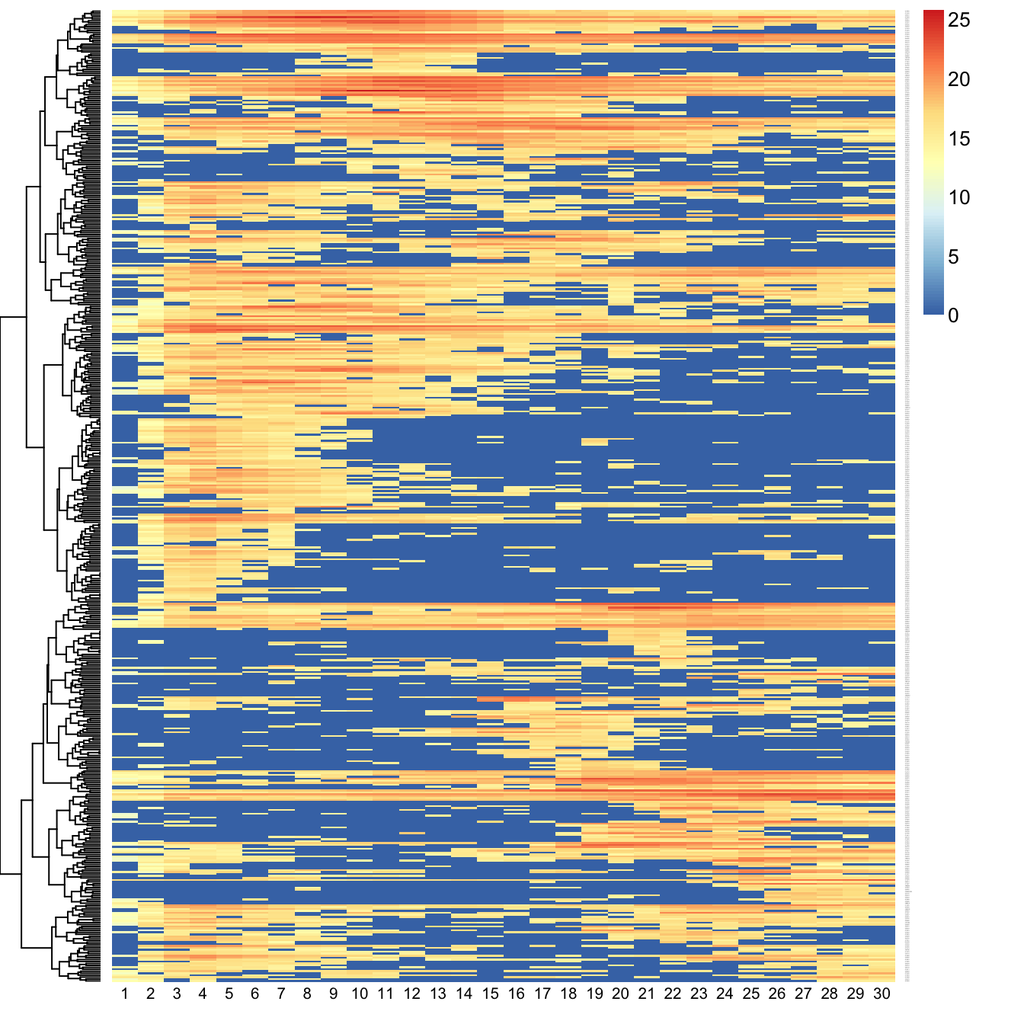

```r
library(NMF)
aheatmap(log1p(wt1_mat[1:500,]), Colv = NA, distfun = "pearson",
         scale = "none")
```

# Check behavior of known complexes. You may have to change the path variable to correctly locate the complexes files.

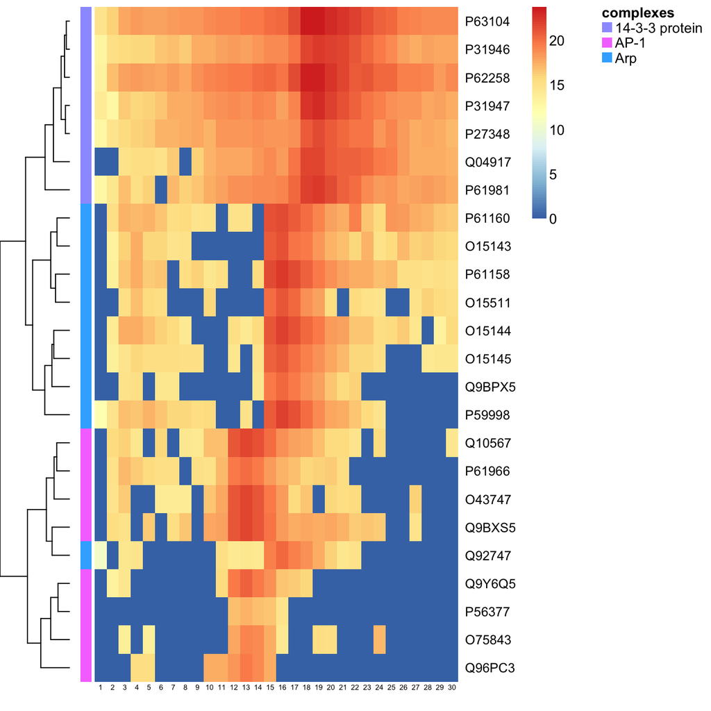

```r
path="/Users/nickgiangreco/GitHub/Proteomic_Correlation_Shiny/eda/"

interacting <- read.table(paste0(path,"interacting_complexes.txt"), sep='\t',
                          stringsAsFactors = FALSE, row.names = 1)
nonint <- read.table(paste0(path,"non-interacting_proteins.txt"), sep='\t',
                     stringsAsFactors = FALSE, row.names = 1)

complexes <- as.factor(interacting[,1])
names(complexes) <- rownames(interacting)

aheatmap(log1p(wt1_mat[rownames(interacting),]), Colv = NA, distfun = "pearson", scale = "none", annRow = data.frame(complexes))
```

```r
pca <- prcomp(log1p(wt1_mat))
d <- as.dist(cor(t(pca$x)))

library(Rtsne)
tsne_data <- Rtsne(d, pca = FALSE, is_distance = TRUE)
```

```r
pal <- clusterExperiment::bigPalette
tsne_points <- tsne_data$Y
rownames(tsne_points) <- rownames(wt1_mat)
plot(tsne_points)
points(tsne_points[names(complexes),], col=pal[complexes], pch=19)
```

[output not shown]

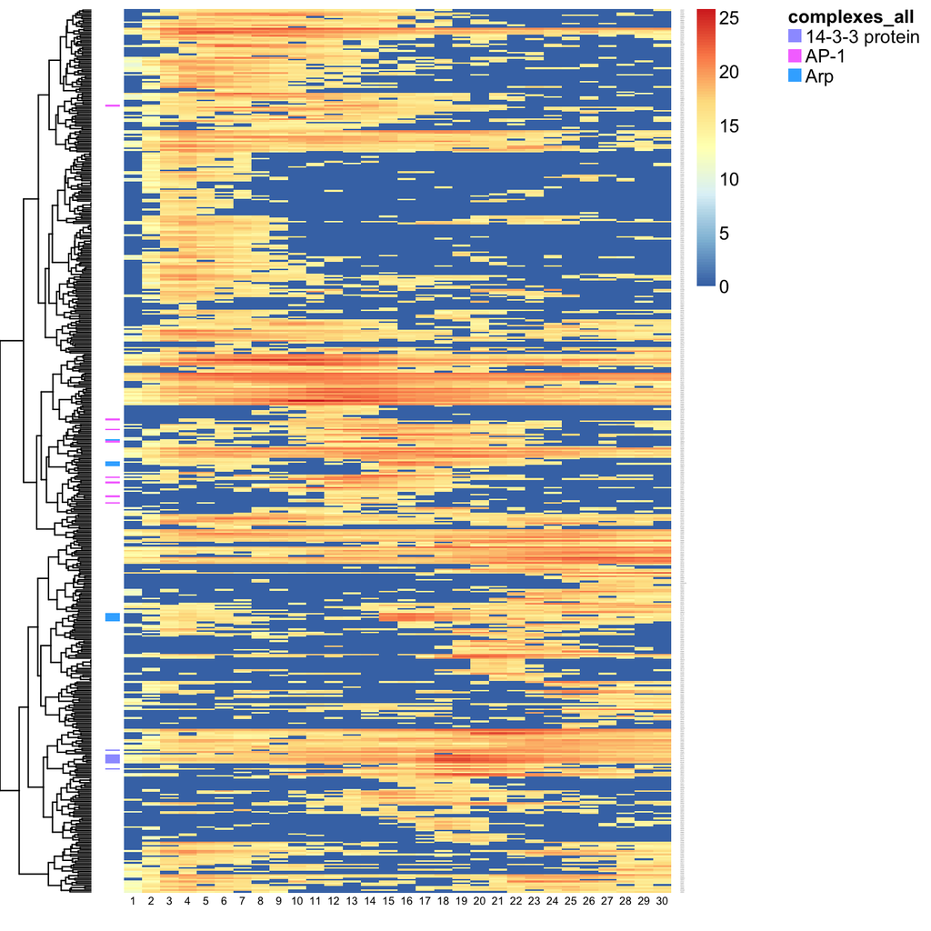

```r
idx <- which(rownames(wt1_mat) %in% names(complexes))
wt1_sub <- wt1_mat[c(idx, setdiff(1:500, idx)), ]

complexes_all <- rep(NA, NROW(wt1_sub))
names(complexes_all) <- rownames(wt1_sub)
complexes_all[names(complexes)] <- as.character(complexes)

aheatmap(log1p(wt1_sub), Colv = NA, distfun = "pearson",
         scale = "none", annRow = data.frame(complexes_all))
```

# Random ideas to improve the analysis

- We should integrate across replicates: e.g., mean profile with some sort of weight for uncertainty.
- Another way would be to cluster based on a tridimensional array proteins times fractions times samples. And use average just for visualization.
- Add a more supervised approach, where we start from a known complex and we add new proteins that have a similar profile.
- In the supervised analysis we could have a voting system to decide whether to include a protein in the complex.

```r
mq.y.1 <- read.MQ.data(filename = system.file("extdata", "test_data", "proteinGroups_100mM_new.txt", package = "DepLab"), expt.id = "100mM", data.subset = "poi", organism = "yeast")
mq.y.3 <- read.MQ.data(filename = system.file("extdata", "test_data", "proteinGroups_300mM_new.txt", package = "DepLab"), expt.id = "300mM", data.subset = "poi", organism = "yeast")
# make one long data.frame/data.table
mqcombi <- rbind(mq.y.1, mq.y.3)

# superSmoother
smu <- superSmooth_values(long.df = subset(mqcombi, measurement == "raw.intensity"), prot.identifier = "gene_symbol")

# fraction normalization or spike-in (see help of normalize_values)
fraction.norm <- normalize_values(long.df = smu,
                                  norm.type = "fraction", prot.identifier = "gene_symbol")
```